# Homework 6

4375 Machine Learning with Dr. Mazidi

Cris Chou

# Problem 1: Comparison with Linear Regression

### Step 1. Load Auto data and make train/test split

Using the Auto data in package ISLR, set seed to 1234 and divide into 75% train, 25% test

```r
# your code here
df <- ISLR :: Auto
set.seed(1234)
i <- sample(1:nrow(df), nrow(df)*.75,replace=FALSE)
train <- df[i,]
test <- df[-i,]
```

### Step 2. Build linear regression model

Build a linear regression model on the train data, with mpg as the target, and cylinders, displacement, and horsepower as the predictors. Output a summary of the model and plot the model to look at the residuals plots.

```r
# your code here
lm1 <- lm(mpg~cylinders+displacement+horsepower,data = train)
summary(lm1)
```

```
##
## Call:
## lm(formula = mpg ~ cylinders + displacement + horsepower, data = train)
##
## Residuals:
##      Min       1Q   Median       3Q      Max
## -11.4207  -3.1426  -0.2873   2.2997  16.8950
##
## Coefficients:
##               Estimate Std. Error t value Pr(>|t|)
## (Intercept)  40.118273   1.484992  27.016  < 2e-16 ***
## cylinders    -1.078971   0.490277  -2.201   0.0285 *
## displacement -0.020006   0.009753  -2.051   0.0411 *
## horsepower   -0.067336   0.015062  -4.471 1.12e-05 ***
## ---
## Signif. codes:  0 '***' 0.001 '**' 0.01 '*' 0.05 '.' 0.1 ' ' 1
##
## Residual standard error: 4.488 on 290 degrees of freedom
## Multiple R-squared:  0.6718, Adjusted R-squared:  0.6685
## F-statistic: 197.9 on 3 and 290 DF,  p-value: < 2.2e-16
```

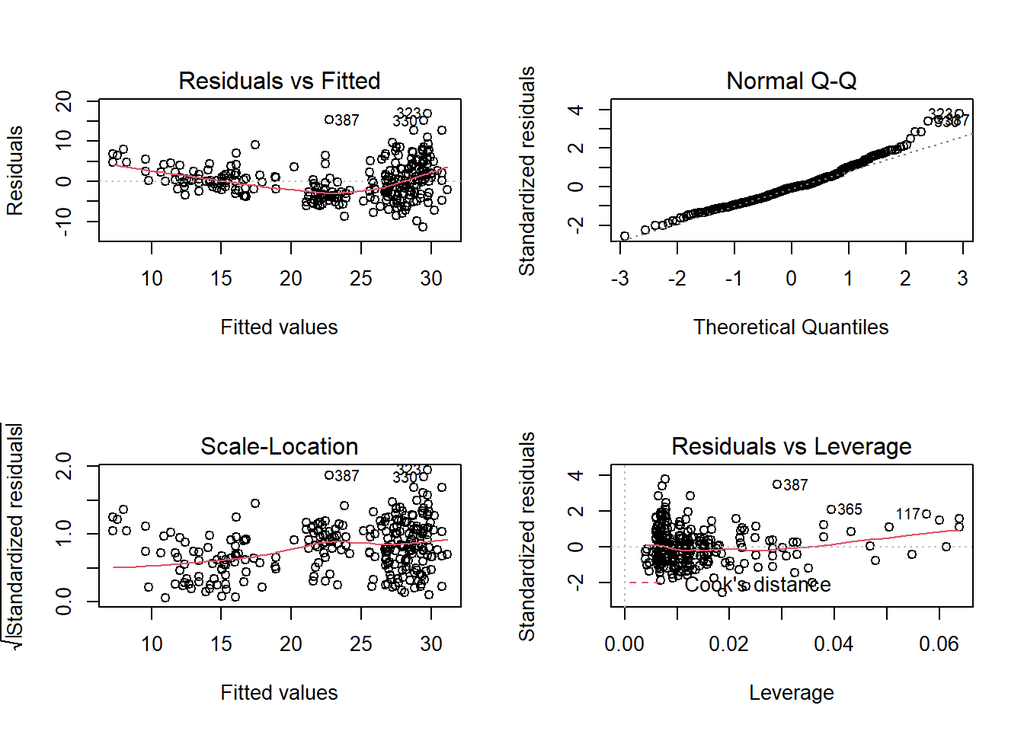

```r
par(mfrow=c(2,2))
plot(lm1)
```

### Step 3. Evaluate on the test data

Evaluate the model on the test data. Output correlation and mse.

```r
# your code here
pred <- predict(lm1,newdata= test)
corr <- cor(pred,test$mpg)
cat("The correlation is ",corr,"\n")
```

```
## The correlation is  0.8058261
```

```r
mse1 <- mean((pred-test$mpg)^2)
cat("The mse was ",mse1)
```

```
## The mse was  21.75834
```

### Step 4. Try knn

Use knnreg() in library caret to fit the training data. Use the default k=1. Output your correlation and mse.

```r
# your code here
library(caret)
fit1 <- knnreg(train[,2:4],train[,1],k=1)
knnPred <- predict(fit1,test[2:4])
corr2 <- cor(knnPred,test$mpg)
mse2 <- mean((knnPred - test$mpg)^2)
cat("The correlation was ",corr2,"\n")
```

```
## The correlation was  0.8437078
```

```r
cat("The mse was ",mse2)
```

```
## The mse was  18.96101
```

### Step 5. Analysis

1. Compare correlation metric that each algorithm achieved. Your commentary here: The correlation for the knn model was higher than the one for the linear model
2. Compare the mse metric that each algorithm achieved. Your commentary here: The mse was also lower for the knn model than the linear model
3. Why do you think that the mse metric was so different compared to the correlation metric? Your commentary here: Lower mse is better and the correlation was higher for the knn model. It makes sense that because of this that the mse would be lower for the knn model since it only had 1 point.
4. Why do you think that kNN outperformed linear regresssion on this data? In your 2-3 sentence explanation, discuss bias of the algorithms. Your commentary here: kNN outperformed because it only used 1 neighbor meaning that the variance is much higher and the bias is lower since its only looking at 1 data point where as the linear model is high bias low variance because the linear model assumes that the model is linear.